# Non-spatial and Spatial Linear Regression

NSC-R workshop

Wouter Steenbeek, Stijn Ruiter

Sep 30, 2021

# 1 (Install and) load packages

We use the package `pacman` to install and load a number of packages.

```r
# install.packages("pacman") # run this line if not already installed

pacman::p_load(tidyverse, tmap, sf, spdep, spatialreg, classInt, jtools, sandwich, broom.mixed, lmtest, MASS, ggstance)
```

# 2 Load data, and plot data

We use data from Washington, D.C. The units of analysis are hexagons that we created ourselves, covering Washington, D.C. For detailed steps that generate the data used, and a discussion of units of analysis for spatial data, please see the supplementary material on https://osf.io/z2347/.

```r
hex_sf <- readRDS("NSCR-R_workshop_regression_20210930_hex_sf.rds")
```

We use package `tmap` to create a dynamic map, using OpenStreetMap as a background layer.

```r
tmap_mode("view") # switch to tmap view mode

tm_shape(hex_sf) + tm_borders(col = "blue", lwd = 1) +
  tm_scale_bar(position = c("right", "bottom")) +
  tm_basemap("OpenStreetMap")
```

[interactive chart not shown]

Our outcome variable of interest is the average annual robbery count in 2015-2019 per areal unit. Criminological literature suggests that robberies are more likely to occur at or close to places with liquor licensee locations, and that will be our predictor variable. Let’s plot these two variables on the map op Washington, D.C. We use `classInt::classIntervals()` to cut the counts into five categories using the Jenks algorithm, and the `viridisLite` package to get the viridis color palette. We use the `alpha` option to specify semi-transparency.

```r
# cut robbery and frequency of liquor stores into categories
hex_sf <- hex_sf %>%
  mutate(robbery_cut = cut(robbery, breaks = classInt::classIntervals(robbery, n = 5,
                           style = "jenks")$brks, include.lowest = TRUE)) %>%
  mutate(liquor_cut = cut(liquor, breaks = classInt::classIntervals(liquor, n = 5,
                          style = "jenks")$brks, include.lowest = TRUE))
```

```r
tm_shape(hex_sf) + tm_polygons("robbery_cut",
                               palette = viridisLite::viridis(5),
                               alpha = .7, lwd = .2) +
  tm_scale_bar(position = c("right", "bottom")) +
  tm_basemap("OpenStreetMap")
```

[interactive chart not shown]

```r
tm_shape(hex_sf) + tm_polygons("liquor_cut",
                               palette = viridisLite::viridis(5),
                               alpha = .7, lwd = .2) +
  tm_scale_bar(position = c("right", "bottom")) +
  tm_basemap("OpenStreetMap")
```

[interactive chart not shown]

At first sight, there seems to be some overlap between the two distributions.

Let’s take a look at the underlying data:

```r
# Note that select(robber, liquor) doesn't work by itself,
# because dplyr::select() is masked by MASS::select
hex_sf %>% st_drop_geometry() %>% dplyr::select(robbery, liquor)
```

|  | robbery | liquor |
| --- | --- | --- |
| 1 | 0.0 | 0 |
| 2 | 0.0 | 0 |
| 3 | 0.0 | 0 |
| 4 | 0.0 | 0 |
| 5 | 0.6 | 2 |
| 6 | 0.0 | 0 |
| 7 | 0.0 | 0 |
| 8 | 0.8 | 9 |
| 9 | 0.2 | 0 |
| 10 | 0.0 | 0 |

[output cut: 264 more lines]

For now, let’s *ignore* the spatial information in the data. I.e., inspect a scatterplot of the two variables. We plot the *non-spatial* bivariate relationship between these two variables:

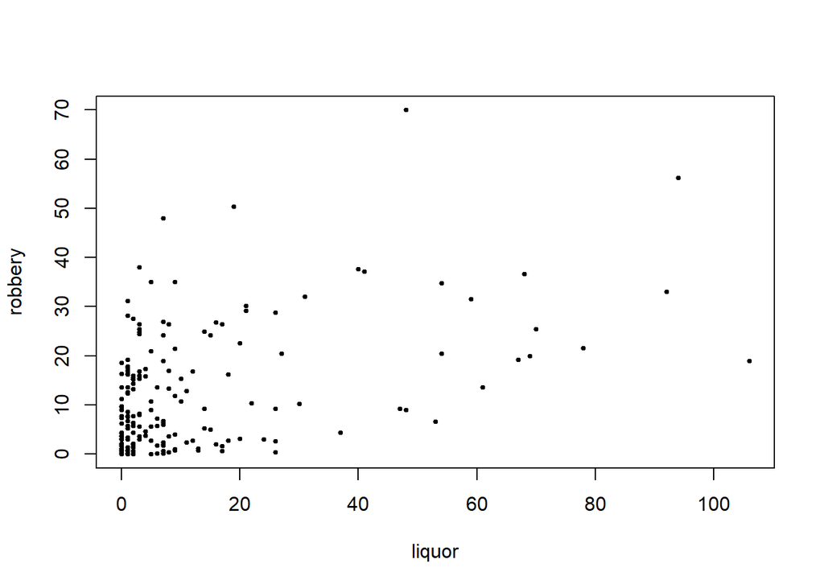

```r
with(hex_sf, plot(liquor, robbery,pch=19,cex=.5))
```

This plot suggest a relationship between liquor licensee locations and robbery. Hexagons with a larger number of liquor licensee locations tend to have a higher average robbery count.

# 3 Regression analysis with one predictor variable

In R, a linear OLS regression model is fitted using `lm(formula = ..., data = ..., ...)`. See `?lm` for details.

```r
# regress robbery count on number of liquor stores in each hexagon
# save in object my_model
my_model <- lm(robbery ~ liquor, hex_sf)
# print summary of the regression results
summary(my_model)
```

```
##
## Call:
## lm(formula = robbery ~ liquor, data = hex_sf)
##
## Residuals:
##     Min      1Q  Median      3Q     Max
## -23.951  -5.344  -4.344   3.676  47.626
##
## Coefficients:
##             Estimate Std. Error t value Pr(>|t|)
## (Intercept)  5.34401    0.64130   8.333 3.93e-15 ***
## liquor       0.35479    0.03438  10.319  < 2e-16 ***
## ---
## Signif. codes:  0 '***' 0.001 '**' 0.01 '*' 0.05 '.' 0.1 ' ' 1
##
## Residual standard error: 9.599 on 272 degrees of freedom
## Multiple R-squared:  0.2813, Adjusted R-squared:  0.2787
## F-statistic: 106.5 on 1 and 272 DF,  p-value: < 2.2e-16
```

We plot the bivariate relationship and the best-fitting line:

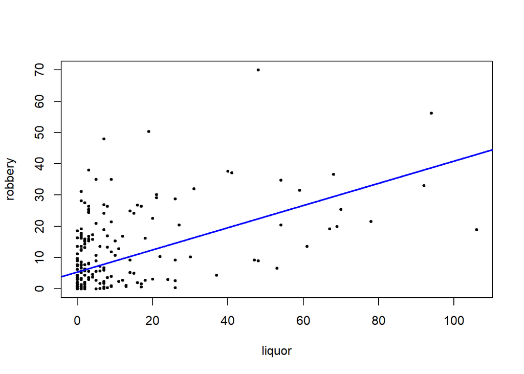

```r
with(hex_sf, plot(liquor, robbery,pch=19,cex=.5)) # scatterplot
abline(my_model, col = "blue", lwd = 2) # add regression line
```

# 4 Multiple regression

Multiple regression is estimated using:

```r
my_model <- lm(robbery ~ liquor + grocery + school + atm_fac, data = hex_sf)
summary(my_model)
```

```
##
## Call:
## lm(formula = robbery ~ liquor + grocery + school + atm_fac, data = hex_sf)
##
## Residuals:
##     Min      1Q  Median      3Q     Max
## -20.183  -2.840  -2.440   2.082  33.811
##
## Coefficients:
##             Estimate Std. Error t value Pr(>|t|)
## (Intercept)   2.8395     0.6076   4.673 4.69e-06 ***
## liquor        0.2197     0.0384   5.720 2.83e-08 ***
## grocery       4.1384     1.0514   3.936 0.000106 ***
## school        5.4645     0.6248   8.746 2.45e-16 ***
## atm_fac       1.2987     1.5018   0.865 0.387936
## ---
## Signif. codes:  0 '***' 0.001 '**' 0.01 '*' 0.05 '.' 0.1 ' ' 1
##
## Residual standard error: 8.118 on 269 degrees of freedom
## Multiple R-squared:  0.4917, Adjusted R-squared:  0.4842
## F-statistic: 65.06 on 4 and 269 DF,  p-value: < 2.2e-16
```

We could standardize a continuous predictor variable $x$ by subtracting its mean and then dividing by its standard deviation $sd(x)$.

```r
hex_sf_z <- hex_sf %>%
  mutate(liquor = (liquor - mean(liquor)) / sd(liquor),
         grocery = (grocery - mean(grocery)) / sd(grocery),
         school = (school - mean(school)) / sd(school))

my_model_z <- lm(robbery ~ liquor + grocery + school + atm_fac, data = hex_sf_z)
summary(my_model_z)
```

```
##
## Call:
## lm(formula = robbery ~ liquor + grocery + school + atm_fac, data = hex_sf_z)
##
## Residuals:
##     Min      1Q  Median      3Q     Max
## -20.183  -2.840  -2.440   2.082  33.811
##
## Coefficients:
##             Estimate Std. Error t value Pr(>|t|)
## (Intercept)   7.8376     0.6227  12.587  < 2e-16 ***
## liquor        3.7117     0.6489   5.720 2.83e-08 ***
## grocery       2.2592     0.5740   3.936 0.000106 ***
## school        4.4578     0.5097   8.746 2.45e-16 ***
## atm_fac       1.2987     1.5018   0.865 0.387936
## ---
## Signif. codes:  0 '***' 0.001 '**' 0.01 '*' 0.05 '.' 0.1 ' ' 1
##
## Residual standard error: 8.118 on 269 degrees of freedom
## Multiple R-squared:  0.4917, Adjusted R-squared:  0.4842
## F-statistic: 65.06 on 4 and 269 DF,  p-value: < 2.2e-16
```

We use the function `plot_summs()` from the package `jtools` to show the standardized regression parameters with their corresponding confidence intervals graphically. Three types of confidence intervals are presented.

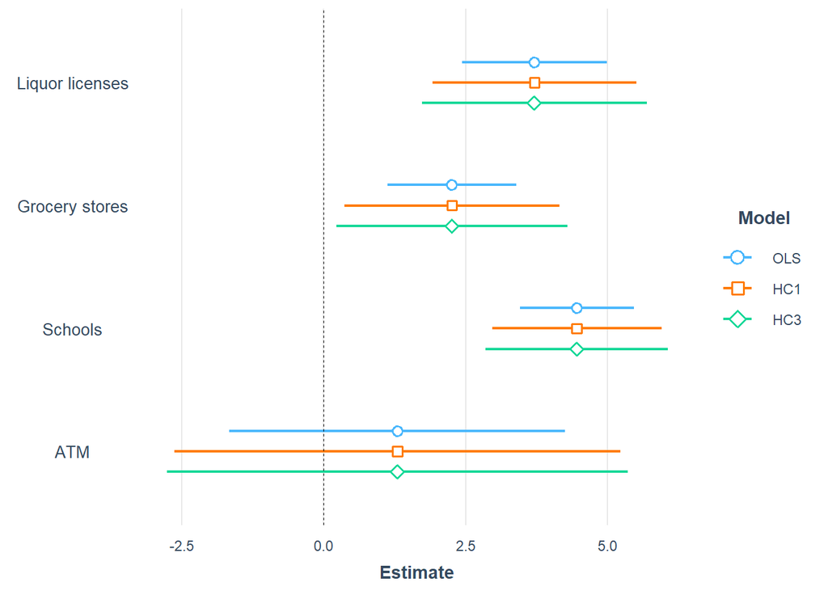

```r
jtools::plot_summs(my_model, my_model, my_model, scale = TRUE,
                   robust = list(FALSE, "HC1", "HC3"),
                   model.names = c("OLS", "HC1", "HC3"),
                   coefs=c("Liquor licenses" = "liquor",
                           "Grocery stores" = "grocery",
                           "Schools"="school",
                           "ATM"="atm_fac"))
```

# 5 Model diagnostics

A range of model diagnostics can be accessed easily by using the `plot()` function, which can handle `lm` objects:

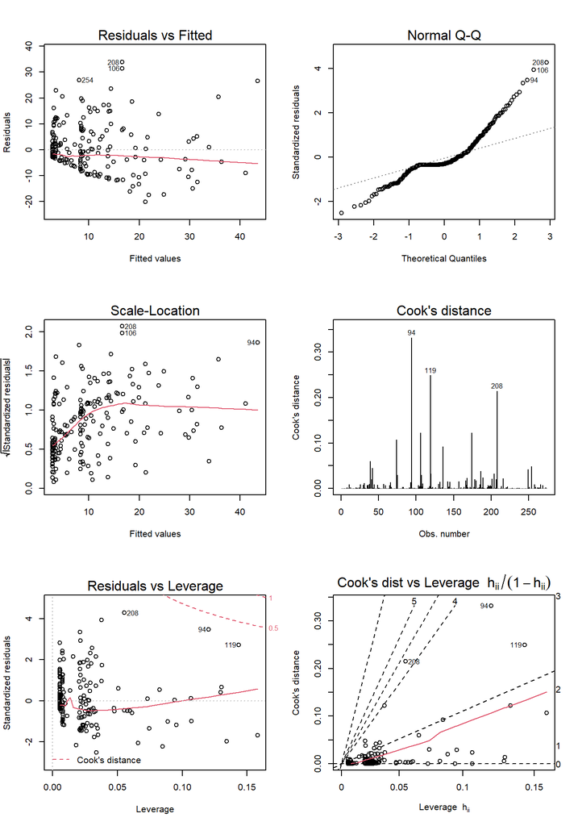

```r
par(mfrow=c(3,2)) # print next plots in 3 rows and 2 columns
plot(my_model, which = 1:6)
par(mfrow=c(1,1)) # print next plots one at a time
```

We also refer to a number of functions from the packages `car` and `lmtest` (note you need to install `car` and `lmtest` first using `install.packages("car")` and `install.packages("lmtest")` if not already installed). In addition, see R package `olsrr` that incorporates a variety of diagnostic tests for OLS regression models. See https://cran.r-project.org/web/packages/olsrr/vignettes/intro.html for an introduction to this package.

```r
car::residualPlots(my_model)
# Breusch-Pagan tests
lmtest::bptest(my_model)
car::ncvTest(my_model)
# Multicollinearity
car::vif(my_model)
# Outliers and Influence plots
car::outlierTest(my_model)
# The `car` package provides the `influencePlot()` function to display the
# Cook's distance, studentized residuals, and leverage of all cases in a
# single plot, and the `dfbetaPlots()` function to assess whether the model
# parameters would change much by excluding cases from the model.
car::influencePlot(my_model)
car::dfbetaPlots(my_model)
```

# 6 Intermezzo: generalized linear models

For these data, we might want to consider *generalized linear models* such as logistic regression, Poisson regression, and Negative binomial regression.

A *logistic regression model* is estimated using:

```r
# First, we need to create the dichotomous outcome variable from the average robbery count over the five years
hex_sf <- hex_sf %>% mutate(robbery_dich = robbery>0)

# Note: After the next line R returns a warning, usually indicating that one or more predictor variables perfectly separate robbery == NO vs robbery == YES.
summary(my_logistic_model <- glm(robbery_dich ~ liquor + grocery + school + atm_fac, data = hex_sf, family = "binomial"))
```

```
##
## Call:
## glm(formula = robbery_dich ~ liquor + grocery + school + atm_fac,
##     family = "binomial", data = hex_sf)
##
## Deviance Residuals:
##      Min        1Q    Median        3Q       Max
## -2.33521   0.00000   0.00001   0.47214   1.44258
##
## Coefficients:
##              Estimate Std. Error z value Pr(>|z|)
## (Intercept)   -0.0379     0.1905  -0.199  0.84226
## liquor         1.0879     0.2978   3.653  0.00026 ***
## grocery       15.0989  1893.0534   0.008  0.99364
## school        18.6333  1747.6431   0.011  0.99149
## atm_fac       -2.7426     1.3458  -2.038  0.04157 *
## ---
## Signif. codes:  0 '***' 0.001 '**' 0.01 '*' 0.05 '.' 0.1 ' ' 1
##
## (Dispersion parameter for binomial family taken to be 1)
##
##     Null deviance: 293.04  on 273  degrees of freedom
## Residual deviance: 179.56  on 269  degrees of freedom
## AIC: 189.56
##
## Number of Fisher Scoring iterations: 20
```

Count models like the *Poisson* and *Negative binomial model* assume that the outcome variable has integer values. Therefore, let’s estimate the models on `robbery_sum`, the sum of all robbery counts within each hexagon over the study period. A Poisson model is estimated using:

```r
summary(my_poisson_model <- glm(robbery_sum ~ liquor + grocery + school + atm_fac, family = "poisson", data = hex_sf))
```

```
##
## Call:
## glm(formula = robbery_sum ~ liquor + grocery + school + atm_fac,
##     family = "poisson", data = hex_sf)
##
## Deviance Residuals:
##     Min       1Q   Median       3Q      Max
## -12.295   -6.464   -4.182    2.020   18.897
##
## Coefficients:
##             Estimate Std. Error z value Pr(>|z|)
## (Intercept) 3.039432   0.014693  206.86   <2e-16 ***
## liquor      0.013049   0.000458   28.49   <2e-16 ***
## grocery     0.194628   0.012102   16.08   <2e-16 ***
## school      0.400144   0.007900   50.65   <2e-16 ***
## atm_fac     0.405457   0.026419   15.35   <2e-16 ***
## ---
## Signif. codes:  0 '***' 0.001 '**' 0.01 '*' 0.05 '.' 0.1 ' ' 1
##
## (Dispersion parameter for poisson family taken to be 1)
##
##     Null deviance: 18084  on 273  degrees of freedom
## Residual deviance: 10889  on 269  degrees of freedom
## AIC: 11957
##
## Number of Fisher Scoring iterations: 6
```

The Poisson regression model rests on the assumption that the conditional variance and conditional mean are equal (i.e. no overdispersion). If this assumption does not hold, the negative binomial model might better fit the data. A negative binomial model is estimated using the `glm.nb` function from the `MASS` package.

```r
summary(my_negbin_model <- MASS::glm.nb(robbery_sum ~ liquor + grocery + school + atm_fac, data = hex_sf))
```

```
##
## Call:
## MASS::glm.nb(formula = robbery_sum ~ liquor + grocery + school +
##     atm_fac, data = hex_sf, init.theta = 0.4337680768, link = log)
##
## Deviance Residuals:
##     Min       1Q   Median       3Q      Max
## -1.8698  -1.2059  -0.5125   0.2232   2.0292
##
## Coefficients:
##             Estimate Std. Error z value Pr(>|z|)
## (Intercept) 2.766592   0.115009  24.055  < 2e-16 ***
## liquor      0.016955   0.007202   2.354   0.0186 *
## grocery     0.373470   0.197161   1.894   0.0582 .
## school      0.699311   0.117251   5.964 2.46e-09 ***
## atm_fac     0.325296   0.282608   1.151   0.2497
## ---
## Signif. codes:  0 '***' 0.001 '**' 0.01 '*' 0.05 '.' 0.1 ' ' 1
##
## (Dispersion parameter for Negative Binomial(0.4338) family taken to be 1)
##
##     Null deviance: 400.36  on 273  degrees of freedom
## Residual deviance: 320.35  on 269  degrees of freedom
## AIC: 2313.7
##
## Number of Fisher Scoring iterations: 1
##
##
##               Theta:  0.4338
##           Std. Err.:  0.0381
##
##  2 x log-likelihood:  -2301.6510
```

Because the Poisson model is nested in the negative binomial model, we can use a Likelihood Ratio test to compare the two models and test whether the Poisson model’s assumption holds.

```r
pchisq(2 * (logLik(my_negbin_model) - logLik(my_poisson_model)), df = 1, lower.tail = FALSE)
```

```
## 'log Lik.' 0 (df=6)
```

We can get the confidence intervals for the coefficients of the Negative binomial model by profiling the likelihood function:

```r
(est <- cbind(Estimate = coef(my_negbin_model), confint(my_negbin_model)))
```

```
##               Estimate         2.5 %     97.5 %
## (Intercept) 2.76659190  2.5294519986 3.01791380
## liquor      0.01695514  0.0031834272 0.03351242
## grocery     0.37346963 -0.0009555669 0.79499215
## school      0.69931059  0.4385156728 0.98590284
## atm_fac     0.32529633 -0.1691344900 0.85928910
```

Incident Rate Ratios are obtained by exponentiating the parameters:

```r
exp(est)
```

```
##              Estimate      2.5 %    97.5 %
## (Intercept) 15.904338 12.5466287 20.448587
## liquor       1.017100  1.0031885  1.034080
## grocery      1.452766  0.9990449  2.214424
## school       2.012365  1.5504042  2.680231
## atm_fac      1.384441  0.8443953  2.361481
```

This tutorial is about showcasing a number of modeling techniques in $R$, focusing on linear regression and linear spatial regression. As such, we do not go into detail about which model we would choose to analyze these data, and instead switch back to the standard linear regression approach we used earlier. So, let’s continue with `my_model`.

# 7 Spatial dependence

We will use $R$ to (1) create 1st-order neighbors of all hexagons covering Washington, D.C. and (2) create a “W” (row-standardized) weights matrix.

```r
# create spatial 1st order rook contiguity neighbors
hex_nb <- spdep::poly2nb(hex_sf, queen = FALSE)

# spatial weights using coding scheme "W"
my_weights <- spdep::nb2listw(hex_nb, style = "W")
```

We use the function `moran.plot()` to create the Moran scatter plot of our OLS residuals on the $x$-axis and their spatially lagged values on the $y$-axis. The plot is divided into quadrants that indicate how the OLS residuals and their spatial lags correlate.

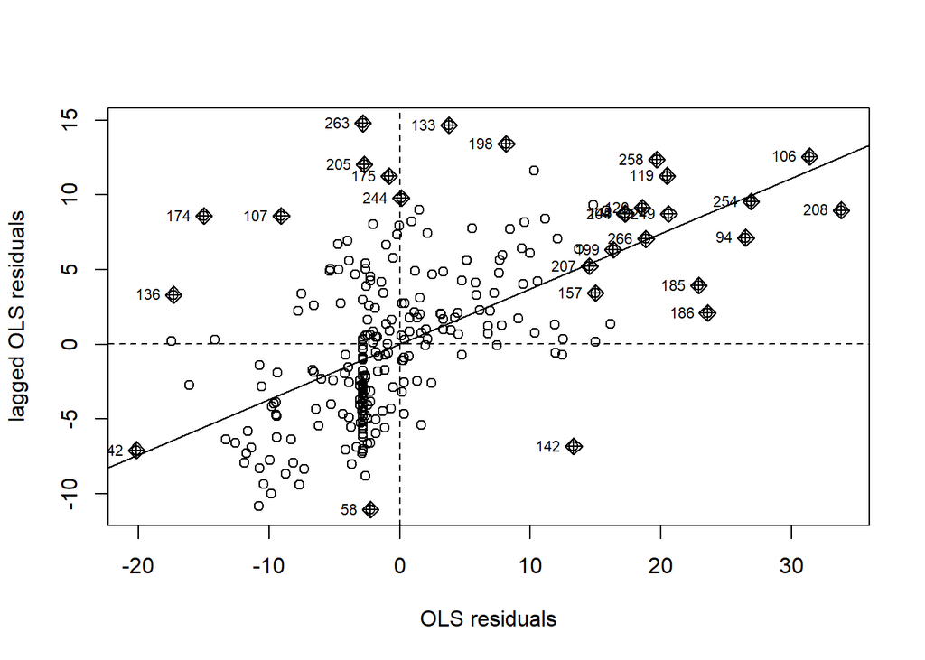

```r
mp <- moran.plot(residuals(my_model), listw = my_weights,
                 cex = 1, xlab = "OLS residuals", ylab = "lagged OLS residuals")
```

The global Moran’s $I$ value reflects the linear relationship between the $x$ and $y$ values in the plot, which itself is again a slope of a regression line through the data points in the plot. A two-sided test on the OLS residuals:

```r
# two-sided moran.test
(my_model_lm_moran <- lm.morantest(my_model,
                                   my_weights,
                                   alternative = "two.sided"))
```

```
##
##  Global Moran I for regression residuals
##
## data:
## model: lm(formula = robbery ~ liquor + grocery + school + atm_fac, data
## = hex_sf)
## weights: my_weights
##
## Moran I statistic standard deviate = 10.275, p-value < 2.2e-16
## alternative hypothesis: two.sided
## sample estimates:
## Observed Moran I      Expectation         Variance
##      0.370288114     -0.006502667      0.001344666
```

The statistic is positive and statistically significant, indicating that hexagons with positive OLS residuals—i.e. more robbery than expected—are typically surrounded by hexagons that also experience more-than-expected robbery.

# 8 Spatial regression

The current regression model doesn’t “solve” the spatial dependence in the data. How to go from here is not straightforward! See chapter & supplementary material for more discussion.

Now, we turn to models that can incorporate spatial dependency. Spatial regression analysis functions are found in the `spatialreg` package.

| Dep. var | Non-spatial Predictor variables | Spatially-lagged predictor variables | Spatially-lagged outcome variable | Spatial error | Random error | Model | Function |
| --- | --- | --- | --- | --- | --- | --- | --- |
| $y=$ | $\mathbf{X}\beta\ +$ |  |  |  | $\epsilon$ | Ordinary Least Squares (OLS) | `lm(...)` |
| $y=$ | $\mathbf{X}\beta\ +$ | $\theta\mathbf{W}\mathbf{X}\ +$ |  |  | $\epsilon$ | Spatially-lagged X (SLX) | `lmSLX(...)` |
| $y=$ | $\mathbf{X}\beta\ +$ |  | $\mathbf{\delta}\mathbf{W}y\ +$ |  | $\epsilon$ | Spatial Lag Model (SLM) | `lagsarlm(..., Durbin = FALSE)` |
| $y=$ | $\mathbf{X}\beta\ +$ |  |  | $\lambda\mathbf{W}u\ +$ | $\epsilon$ | Spatial Error Model (SEM) | `errorsarlm(..., Durbin = FALSE)` or `spautolm(..., family = "SAR")` |
| $y=$ | $\mathbf{X}\beta\ +$ | $\theta\mathbf{W}\mathbf{X}\ +$ | $\mathbf{\delta}\mathbf{W}y\ +$ |  | $\epsilon$ | Spatial Durbin Model (SDM) | `lagsarlm(..., Durbin=TRUE)` |
| $y=$ | $\mathbf{X}\beta\ +$ |  | $\mathbf{\delta}\mathbf{W}y\ +$ | $\lambda\mathbf{W}u\ +$ | $\epsilon$ | Spatial Autoregressive Combined (SAC) | `sacsarlm(..., Durbin = FALSE)` |
| $y=$ | $\mathbf{X}\beta\ +$ | $\theta\mathbf{W}\mathbf{X}\ +$ |  | $\lambda\mathbf{W}u\ +$ | $\epsilon$ | Spatial Durbin Error Model (SDEM) | `errorsarlm(..., Durbin = TRUE)` |
| $y=$ | $\mathbf{X}\beta\ +$ | $\theta\mathbf{W}\mathbf{X}\ +$ | $\mathbf{\delta}\mathbf{W}y\ +$ | $\lambda\mathbf{W}u\ +$ | $\epsilon$ | General Nested Model (GNM) | `sacsarlm(..., Durbin = TRUE)` |

# 9 Spatially-lagged X model

The spatially-lagged X model is actually simply an OLS regression that includes one or more spatially-lagged explanatory variables. By using the function `lmSLX` in the `spatialreg` package, R automatically creates the spatially-lagged version of all predictor variables (`liquor`, `grocery`, `school`, and `atm_fac`).

```r
# SLX model for all predictor variables
my_model_slx <- lmSLX(robbery ~ liquor + grocery + school + atm_fac,
                      data = hex_sf, listw = my_weights)
summary(my_model_slx)
```

```
##
## Call:
## lm(formula = formula(paste("y ~ ", paste(colnames(x)[-1], collapse = "+"))),
##     data = as.data.frame(x), weights = weights)
##
## Residuals:
##      Min       1Q   Median       3Q      Max
## -16.3106  -4.0887   0.1123   2.3812  27.5197
##
## Coefficients:
##             Estimate Std. Error t value Pr(>|t|)
## (Intercept) -0.32123    0.68113  -0.472  0.63760
## liquor       0.20215    0.04274   4.730 3.65e-06 ***
## grocery      2.85805    0.91879   3.111  0.00207 **
## school       4.59601    0.55389   8.298 5.44e-15 ***
## atm_fac      1.21182    1.34566   0.901  0.36865
## lag.liquor   0.04549    0.07412   0.614  0.53996
## lag.grocery  2.50125    2.44952   1.021  0.30813
## lag.school  10.70202    1.19086   8.987  < 2e-16 ***
## lag.atm_fac -7.10177    2.79308  -2.543  0.01157 *
## ---
## Signif. codes:  0 '***' 0.001 '**' 0.01 '*' 0.05 '.' 0.1 ' ' 1
##
## Residual standard error: 6.983 on 265 degrees of freedom
## Multiple R-squared:  0.6295, Adjusted R-squared:  0.6183
## F-statistic: 56.29 on 8 and 265 DF,  p-value: < 2.2e-16
```

# 10 Choice of spatial model

*Lagrange Multiplier test* (LM) statistics can be used to suggest whether the data generating process is better captured using a spatial error or a spatial lag model. The `lm.LMtests()` function in the `spdep` package needs a regression object and a spatial weights object. The procedure can perform multiple LM tests at the same time using `lm.LMtests(my_model_slx, my_lw, test = c("LMerr","RLMerr","LMlag","RLMlag"))`:

```r
# run LM tests
res <- lm.LMtests(my_model_slx, listw = my_weights,
                  test = c("LMerr","RLMerr","LMlag","RLMlag"))

# Make output a little prettier
tres <- t(sapply(res, function(x) c(x$statistic, x$parameter, x$p.value)))
colnames(tres) <- c("Statistic", "df", "p-value")

# print output
tres
```

```
##        Statistic df      p-value
## LMerr  53.258538  1 2.924327e-13
## RLMerr  1.446902  1 2.290258e-01
## LMlag  68.663622  1 1.110223e-16
## RLMlag 16.851986  1 4.041102e-05
```

Based on these results (see chapter) we proceed to fit a spatial lag model. Because we also include spatially-lagged predictor variables, this means a Spatial Durbin model is specified: `lagsarlm(..., Durbin=TRUE)`.

```r
# Spatial Durbin model
my_model_sdm <- lagsarlm(robbery ~ liquor + grocery + school + atm_fac,
                         data = hex_sf, listw = my_weights, Durbin=TRUE)
# Display model summary
summary(my_model_sdm)
```

```
##
## Call:lagsarlm(formula = robbery ~ liquor + grocery + school + atm_fac,
##     data = hex_sf, listw = my_weights, Durbin = TRUE)
##
## Residuals:
##       Min        1Q    Median        3Q       Max
## -14.00535  -3.12233  -0.11223   2.02426  24.55820
##
## Type: mixed
## Coefficients: (asymptotic standard errors)
##              Estimate Std. Error z value  Pr(>|z|)
## (Intercept) -0.852379   0.583108 -1.4618 0.1438000
## liquor       0.199739   0.036461  5.4781 4.298e-08
## grocery      2.742420   0.784486  3.4958 0.0004726
## school       3.407345   0.486229  7.0077 2.423e-12
## atm_fac      1.814121   1.148977  1.5789 0.1143588
## lag.liquor  -0.119760   0.064543 -1.8555 0.0635235
## lag.grocery  1.084518   2.111308  0.5137 0.6074820
## lag.school   4.535334   1.178654  3.8479 0.0001191
## lag.atm_fac -4.217418   2.383999 -1.7691 0.0768852
##
## Rho: 0.5591, LR test value: 58.3, p-value: 2.2538e-14
## Asymptotic standard error: 0.062011
##     z-value: 9.0161, p-value: < 2.22e-16
## Wald statistic: 81.289, p-value: < 2.22e-16
##
## Log likelihood: -887.5597 for mixed model
## ML residual variance (sigma squared): 35.485, (sigma: 5.9569)
## Number of observations: 274
## Number of parameters estimated: 11
## AIC: 1797.1, (AIC for lm: 1853.4)
## LM test for residual autocorrelation
## test value: 0.38579, p-value: 0.53452
```

# 11 Interpreting spatial regression models: Impacts

We should *not* interpret the regression results table of models that include a spatially-lagged dependent variable—i.e., the results directly above this text—because a one unit change in a predictor variable cascades throughout the system. Instead, the function `impacts()` in the `spatialreg` package decomposes the impact of variables into the *average direct* impact, the *average total* impact, and the *average indirect* impact.

```r
impacts(my_model_sdm, listw = my_weights)
```

```
## Impact measures (mixed, exact):
##            Direct    Indirect      Total
## liquor  0.1985341 -0.01713632  0.1813978
## grocery 3.1323153  5.54748502  8.6798004
## school  4.3665736 13.64805319 18.0146268
## atm_fac 1.3370452 -6.78791373 -5.4508686
```

# 13 References / Copyright

The code for this workshop is based on a book chapter that has been accepted for publication in E.Groff and C. Haberman (Eds.), The study of crime and place: A methods handbook (Temple University Press, 2021). Please see https://osf.io/z2347/ for a pre-print of the chapter and supplementary material.